# MICB425 portfolio

Jessica Ngo (31837131)

version April 10, 2018

# Evidence worksheets

## Evidence Worksheet 1 for “Prokaryotes: The Unseen Majority”

### Learning Objectives

Describe the numerical abundance of microbial life in relation to ecology and biogeochemistry of Earth systems.

### General Questions

#### What were the main questions being asked?

How many microbes are there? Where are these microbes habituated? How much carbon to they amass too?

#### What were the primary methodological approaches used?

- Extrapolation of microbial counts in “representative” samples of specific habitats (from other studies/research… some are unpublished?)
- - from this, they use estimation of total # of microbes to arithmetically estimate the amount of carbon, also using a representative estimated weight/cell and carbon/cell
- original methodology for countin microbes assumed to be direct microscopic counts, measures of turbidity orciable counts
- - nextgen sequencing not a thing yet when this paper was published

#### Summarize the main results or findings.

- estimated 4-6*10^6 prokaryotic cells contributing to 350-550Pg of C - HUGE portion of Earth’s carbon
- distribution of microbes: ** subsurface >> soil > aquatic >>>>>>> air, animal, other habitats
- huge store of nutrients - 10 fold more P and N than plants

#### Do new questions arise from the results?

- How have these numbers change if the study were repeated today? What about with new, different methods, ie. nextgen sequencing? Are the results still the same?

#### Were there any specific challenges or advantages in understanding the paper (e.g. did the authors provide sufficient background information to understand experimental logic, were methods explained adequately, were any specific assumptions made, were conclusions justified based on the evidence, were the figures or tables useful and easy to understand)?

- Where did these numbers come from? What studies did they get these numbers from? How did they get data from unpublished studies that are never referenced?
- If they explained their numbers/calculations/assumptions, that would have been a lot more helpful, rather than the reader guessing/trying to figure it out themselves
- Figures/tables were useful, especially for summarizing numbers across habitats and drawing comparisons

## Evidence Worksheet_02 Life and the Evolution of Earth’s Atmosphere

### Learning Objectives

Comment on the emergence of microbial life and the evolution of Earth systems

### General Questions

- Indicate the key events in the evolution of Earth systems at each approximate moment in the time series. If times need to be adjusted or added to the timeline to fully account for the development of Earth systems, please do so.
  - 4.6 billion years ago
    - solar system begins with one or more local supernova explosions
    - 4.5Ga possible collision leading to moon and seasons/tides
  - 4.2 billion years ago
    - point at which earth could have permanent habituation (or even 4.0ga or less)
  - 3.8 billion years ago
    - until now, earth is constantly bombareded so that all H20 is vapourized or temperature is >110 degrees C
  - 3.75 billion years ago
    - evidence from Isua belt, oldest rocks, evidence of oceans and banded conformations indicating anoxygenic photosynthesis which implies considerable speciation - oldest probable life!
    - however dating is controversial and carbonate is not necssarily the age of the host rock
  - 3.5 billion years ago
    - rubisco signature implies global oxygenic photosynthesis and evolution of cyanobacteria
    - confirmed life exists for at least this long
  - 3.0 billion years ago
    - geologic evidence for archaea, stromatolites
  - 2.7 billion years ago
    - well developed stromatolites found in many places
    - ancestral eukaryotes appear to predate 2.7Ga
    - hydrocarbon biomarkers found, including 2-alpha-methylhopanes are characteristic of cyanobacteria, implying oxygenic photosynthesis is occuring
  - 2.2 billion years ago
    - redbeds do not exist before this point - suggests oxidizing conditions after this time
    - sharp spike in oxygen level, and possibly the appearance of complex eukaryotes
  - 2.1 billion years ago
    - switch from a microaerobic early atmosphere to a oxis air at this point
  - 1.3 billion years ago
    - multicellular life, first multicellular organisms!
  - 550,000 years ago
    - cambrian explosion!! life expansion pack!
  - 200,000 years ago
    - plants and animal on land
- Describe the dominant physical and chemical characteristics of Earth systems at the following waypoints:
  - Hadean
    - hot, external CO2 and vapourized H2O
    - cold glacial temperatures when not bombarded (due to young sun)
    - water hydrolyzes to H2 and O2 and H2 escapes
  - Archean
    - rich in phosphate
    - warmth and UV protection
    - subaerial and subaqueous hydrothermal vents rich in metals
    - sulphur cycle (modern or not?)
  - Precambrian
    - same as above
  - Proterozoic
    - oxygen rapidly increasin, therefore [CH4] in atmosphere decreasing - get glaciation, becomes very cold
    - CO2 also likely decreasing due to photosynthetic microbes
  - Phanerozoic
    - ~22% O2 due to photosynthesis (plants + bacteria)
    - relatively less CO2 than before on a large time scale3
    - N aroudn the same through this point

## Evidence Worksheet 3 for “The Anthropocene”

### Learning Objectives

Evaluate human impacts on the ecology and biogeochemistry of Earth systems.

### General Questions

#### What were the main questions being asked?

#### What were the primary methodological approaches used?

#### Summarize the main results or findings.

#### Do new questions arise from the results?

#### Were there any specific challenges or advantages in understanding the paper (e.g. did the authors provide sufficient background information to understand experimental logic, were methods explained adequately, were any specific assumptions made, were conclusions justified based on the evidence, were the figures or tables useful and easy to understand)?

## Evidence worksheet_04 “Bacterial Rhodopsin Gene Expression”"

### Learning Objectives

Describe the numerical abundance of microbial life in relation to ecology and biogeochemistry of Earth systems. * Discuss the relationship between microbial community structure and metabolic diversity * Evaluate common methods for studying the diversity of microbial communities * Recognize basic design elements in metagenomic workflows

### General Questions

#### What were the main questions being asked?

#### What were the primary methodological approaches used?

#### Summarize the main results or findings.

#### Do new questions arise from the results?

#### Were there any specific challenges or advantages in understanding the paper (e.g. did the authors provide sufficient background information to understand experimental logic, were methods explained adequately, were any specific assumptions made, were conclusions justified based on the evidence, were the figures or tables useful and easy to understand)?

## Evidence Worksheet 5 for “Extensive mosaic structure”

### Learning Objectives

- Evaluate the concept of microbial species based on environmental surveys and cultivation studies.
- Explain the relationship between microdiversity, genomic diversity and metabolic potential
- Comment on the forces mediating divergence and cohesion in natural microbial communities

### General Questions

#### What were the main questions being asked?

#### What were the primary methodological approaches used?

#### Summarize the main results or findings.

#### Do new questions arise from the results?

#### Were there any specific challenges or advantages in understanding the paper (e.g. did the authors provide sufficient background information to understand experimental logic, were methods explained adequately, were any specific assumptions made, were conclusions justified based on the evidence, were the figures or tables useful and easy to understand)?

# Problem sets

### Problem set 01

#### Learning objectives:

Describe the numerical abundance of microbial life in relation to the ecology and biogeochemistry of Earth systems.

#### Specific Questions:

```r
((2.9*10^27)/1.5)*365
```

```
## [1] 7.056667e+29
```

- What is the relationship between carbon content, carbon assimilation efficiency and turnover rates in the upper 200m of the ocean? Why does this vary with depth in the ocean and between terrestrial and marine habitats?
  - higher C assimilation –> higher turnover
    - this is more carbon available due to assimilation, means more carbon available for growth
  - with depth in the ocean
    - increasing depth usually means less carbon assimilation, less carbon available, therefore lower turnover rates (ie. energy through photosynthesis)
    - nutrient availability
    - also temperature can affect metabolism
  - between terrestrial and marine habitats - easier to get nutrients in marine habitat since its in solution, movement of nutrients and more microbes = more nutrients which supports more microbes…
- How were the frequency numbers for four simultaneous mutations in shared genes determined for marine heterotrophs and marine autotrophs given an average mutation rate of 4 x 10-7 per DNA replication? (Provide an example of the calculation with units. Hint: cell and generation cancel out)
  - (4e-7)^4 * 3.6e28cells/16days * 1day/24hours = 2.4/hour of 4 simultaneous mutations in shared genes
- Given the large population size and high mutation rate of prokaryotic cells, what are the implications with respect to genetic diversity and adaptive potential? Are point mutations the only way in which microbial genomes diversify and adapt?
  - HUGE genetic diversity & adaptive potential
  - besides point mutations, there are also indels, inversions, duplications and transpositions for mutational changes
  - on top of this, they also have horizontal gene transfer (HGT) through conjugation or viral infection
- What relationships can be inferred between prokaryotic abundance, diversity, and metabolic potential based on the information provided in the text?
  - positive correlation between abundance, diversity, and metabolic potential

### Problem set_02 âMicrobial Enginesâ

#### Learning objectives:

Discuss the role of microbial diversity and formation of coupled metabolism in driving global biogeochemical cycles.

#### Specific Questions:

- What are the primary geophysical and biogeochemical processes that create and sustain conditions for life on Earth? How do abiotic versus biotic processes vary with respect to matter and energy transformation and how are they interconnected?
1. geophysical (mainly acid/base rxns)
   - tectonics resupply C, S, P
   - geothermal processes resuply C, S and metals
2. biochemical (biologically driven)
   - mainly redox reactions
   - photosynthesis drives oxidation of electron donors (requires energy in the form of light rather than through bond energy)
   - respiration drives reduction of electron donors
   - forms a cycle, although not perfect, resupplemented by geophysical processes
- Why is Earth’s redox state considered an emergent property?
  - originally earth’s chemistry was mainly acid/base and not redox, due to abiotic processes, but with the emergence and addition of microbes, this lead to increase in a redox state world-wide, since microbes increase both oxidized and reduced forms of metabolites
- How do reversible electron transfer reactions give rise to element and nutrient cycles at different ecological scales? What strategies do microbes use to overcome thermodynamic barriers to reversible electron flow?
  - reversibility allows both oxidation and reduction
  - eg. inorganic C + energy <-> organic C
    - therefore, in areas or niches where inorganic C and energy is available, this can be reduced into organic C form through photosynthesis
    - In areas where organic C is more abundant, this can be oxidized into energy and inorganic C
  - on a small scale, there is a cycle between photosynthesis and respiration
  - on a large scale, elements and nutrients are cycled into different forms
  - thermodynamic barriers are overcome by co-operation or distributed metabolic networks, and using light electrons as reducing power
- Using information provided in the text, describe how the nitrogen cycle partitions between different redox “niches” and microbial groups. Is there a relationship between the nitrogen cycle and climate change?
  - N2 -> NH4+ (fixation)
    - group of bacteria that reduces/fixes N2 to NH4+, uses nitrogenase
  - NH4+ -> NO2 (nitrification, also fixes CO2 to CH2O)
    - group of bacteria/archaea that oxidizes NH4+ to NO2, and consumes oxygen in the process
  - NO2 -> NO3 (nitrification)
    - group of bacteria that oxidizes NO2 to NO3, requires oxygen as well, not in competition with previous group due to different electron donor
  - No3 -> N2 (denitrification)
    - reduces NO3 to N2 again through anaerobic oxidation of organic matter
  - in regards to climate change, the burning of fossil fuels, increase of nitrogen fertilizers, etc, have increased the amoun of N in the cycle which leads to an increased accumulation of NH4+, which means increased acidity, and leads to NO3 leaching so that this results in dead fish, and animals/insects also die
- What is the relationship between microbial diversity and metabolic diversity and how does this relate to the discovery of new protein families from microbial community genomes?
  - metabolic diversity would lead to microbial diversity because different types of metabolism would lead to different niches being occupied, and thus difference microbes would arise as a result
  - there is some machinery that is highly conservered amonst all groups, which includes basic electron transductin processes, protein translation, DNA replication, etc.
  - there are also different genes that can lead to increased microbial and metabolic diversity, such as carryon genes and boutique genes (specific to niche)
- On what basis do the authors consider microbes the guardians of metabolism?
  - they are ubiquitous and holy the intructions and capacity for metabolism
  - and in the event of extinction withou complete annihilation they will maintain and guard all the genes and mechanisms necessary for metabolism, and eventually re-establish worldwide
  - HGT can also help maintain pathways

### Problem set_03 âMetagenomics: Genomic Analysis of Microbial Communitiesâ

#### Learning objectives:

Specific emphasis should be placed on the process used to find the answer. Be as comprehensive as possible e.g. provide URLs for web sources, literature citations, etc.  
*(Reminders for how to format links, etc in RMarkdown are in the RMarkdown Cheat Sheets)*

#### Specific Questions:

- How many prokaryotic divisions have been described and how many have no cultured representatives (microbial dark matter)?
- How many metagenome sequencing projects are currently available in the public domain and what types of environments are they sourced from?
- What types of on-line resources are available for warehousing and/or analyzing environmental sequence information (provide names, URLS and applications)?
- What is the difference between phylogenetic and functional gene anchors and how can they be used in metagenome analysis?
- What is metagenomic sequence binning? What types of algorithmic approaches are used to produce sequence bins? What are some risks and opportunities associated with using sequence bins for metabolic reconstruction of uncultivated microorganisms?
- Is there an alternative to metagenomic shotgun sequencing that can be used to access the metabolic potential of uncultivated microorganisms? What are some risks and opportunities associated with this alternative?

### Problem set_04 âFine-scale phylogenetic architectureâ

#### Learning objectives:

- Gain experience estimating diversity within a hypothetical microbial community

#### Outline:

In class Day 1:

1. Define and describe species within your group’s “microbial” community.
2. Count and record individuals within your defined species groups.
3. Remix all species together to reform the original community.
4. Each person in your group takes a random sample of the community (*i.e.* devide up the candy).

Assignment:

5. Individually, complete a collection curve for your sample.
6. Calculate alpha-diversity based on your original total community and your individual sample.

In class Day 2:

7. Compare diversity between groups.

#### Part 1: Description and enumeration

Obtain a collection of “microbial” cells from “seawater”. The cells were concentrated from different depth intervals by a marine microbiologist travelling along the Line-P transect in the northeast subarctic Pacific Ocean off the coast of Vancouver Island British Columbia.

Sort out and identify different microbial “species” based on shared properties or traits. Record your data in this Rmarkdown using the example data as a guide.

Once you have defined your binning criteria, separate the cells using the sampling bags provided. These operational taxonomic units (OTUs) will be considered separate “species”. This problem set is based on content available at [What is Biodiversity](http://cnx.org/content/m12179/latest/).

For example, load in the packages you will use.

```r
#To make tables
library(kableExtra)
library(knitr)
#To manipulate and plot data
library(tidyverse)
```

Then load in the data. You should use a similar format to record your community data.

```r
example_data1 = data.frame(
  number = c(1,2,3),
  name = c("lion", "tiger", "bear"),
  characteristics = c("brown cat", "striped cat", "not a cat"),
  occurences = c(2, 4, 1)
)
```

Finally, use these data to create a table.

```r
example_data1 %>%
  kable("html") %>%
  kable_styling(bootstrap_options = "striped", font_size = 10, full_width = F)
```

| number | name | characteristics | occurences |
| --- | --- | --- | --- |
| 1 | lion | brown cat | 2 |
| 2 | tiger | striped cat | 4 |
| 3 | bear | not a cat | 1 |

For your community:

- Construct a table listing each species, its distinguishing characteristics, the name you have given it, and the number of occurrences of the species in the collection.
- Ask yourself if your collection of microbial cells from seawater represents the actual diversity of microorganisms inhabiting waters along the Line-P transect. Were the majority of different species sampled or were many missed?

#### Part 2: Collector’s curve

To help answer the questions raised in Part 1, you will conduct a simple but informative analysis that is a standard practice in biodiversity surveys. This analysis involves constructing a collector’s curve that plots the cumulative number of species observed along the y-axis and the cumulative number of individuals classified along the x-axis. This curve is an increasing function with a slope that will decrease as more individuals are classified and as fewer species remain to be identified. If sampling stops while the curve is still rapidly increasing then this indicates that sampling is incomplete and many species remain undetected. Alternatively, if the slope of the curve reaches zero (flattens out), sampling is likely more than adequate.

To construct the curve for your samples, choose a cell within the collection at random. This will be your first data point, such that X = 1 and Y = 1. Next, move consistently in any direction to a new cell and record whether it is different from the first. In this step X = 2, but Y may remain 1 or change to 2 if the individual represents a new species. Repeat this process until you have proceeded through all cells in your collection.

For example, we load in these data.

```r
example_data2 = data.frame(
  x = c(1,2,3,4,5,6,7,8,9,10),
  y = c(1,2,3,4,4,5,5,5,6,6)
)
```

And then create a plot. We will use a scatterplot (geom_point) to plot the raw data and then add a smoother to see the overall trend of the data.

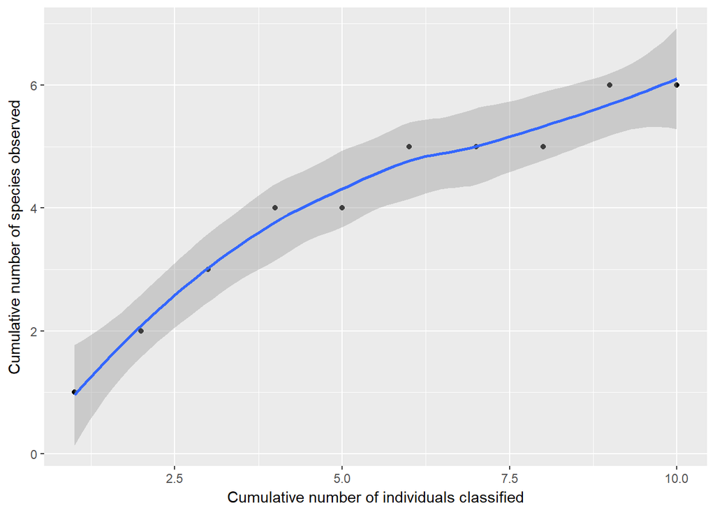

```r
ggplot(example_data2, aes(x=x, y=y)) +
  geom_point() +
  geom_smooth() +
  labs(x="Cumulative number of individuals classified", y="Cumulative number of species observed")
```

For your sample:

- Create a collector’s curve for your sample (not the entire original community).
- Does the curve flatten out? If so, after how many individual cells have been collected?
- What can you conclude from the shape of your collector’s curve as to your depth of sampling?

#### Part 3: Diversity estimates (alpha diversity)

Using the table from Part 1, calculate species diversity using the following indices or metrics.

##### Diversity: Simpson Reciprocal Index

$\frac{1}{D}$ where $D = \sum p_i^2$

$p_i$ = the fractional abundance of the $i^{th}$ species

For example, using the example data 1 with 3 species with 2, 4, and 1 individuals each, D =

```r
species1 = 2/(2+4+1)
species2 = 4/(2+4+1)
species3 = 1/(2+4+1)

1 / (species1^2 + species2^2 + species3^2)
```

```
## [1] 2.333333
```

The higher the value is, the greater the diversity. The maximum value is the number of species in the sample, which occurs when all species contain an equal number of individuals. Because the index reflects the number of species present (richness) and the relative proportions of each species with a community (evenness), this metric is a diveristy metric. Consider that a community can have the same number of species (equal richness) but manifest a skewed distribution in the proportion of each species (unequal evenness), which would result in different diveristy values.

- What is the Simpson Reciprocal Index for your sample?
- What is the Simpson Reciprocal Index for your original total community?

##### Richness: Chao1 richness estimator

Another way to calculate diversity is to estimate the number of species that are present in a sample based on the empirical data to give an upper boundary of the richness of a sample. Here, we use the Chao1 richness estimator.

$S_{chao1} = S_{obs} + \frac{a^2}{2b})$

$S_{obs}$ = total number of species observed a = species observed once b = species observed twice or more

So for our previous example community of 3 species with 2, 4, and 1 individuals each, $S_{chao1}$ =

```r
3 + 1^2/(2*2)
```

```
## [1] 3.25
```

- What is the chao1 estimate for your sample?
- What is the chao1 estimate for your original total community?

#### Part 4: Alpha-diversity functions in R

We’ve been doing the above calculations by hand, which is a very good exercise to aid in understanding the math behind these estimates. Not surprisingly, these same calculations can be done with R functions. Since we just have a species table, we will use the `vegan` package. You will need to install this package if you have not done so previously.

```r
library(vegan)
```

First, we must remove the unnecesary data columns and transpose the data so that `vegan` reads it as a species table with species as columns and rows as samples (of which you only have 1).

```r
example_data1_diversity =
  example_data1 %>%
  select(name, occurences) %>%
  spread(name, occurences)

example_data1_diversity
```

```
##   bear lion tiger
## 1    1    2     4
```

Then we can calculate the Simpson Reciprocal Index using the `diversity` function.

```r
diversity(example_data1_diversity, index="invsimpson")
```

```
## [1] 2.333333
```

And we can calculate the Chao1 richness estimator (and others by default) with the the `specpool` function for extrapolated species richness. This function rounds to the nearest whole number so the value will be slightly different that what you’ve calculated above.

```r
specpool(example_data1_diversity)
```

```
##     Species chao chao.se jack1 jack1.se jack2 boot boot.se n
## All       3    3       0     3        0     3    3       0 1
```

In Project 1, you will also see functions for calculating alpha-diversity in the `phyloseq` package since we will be working with data in that form.

For your sample:

- What are the Simpson Reciprocal Indices for your sample and community using the R function?
- What are the chao1 estimates for your sample and community using the R function?
  - Verify that these values match your previous calculations.

#### Part 5: Concluding activity

If you are stuck on some of these final questions, reading the [Kunin et al. 2010](https://www.ncbi.nlm.nih.gov/pubmed/19725865) and [Lundin et al. 2012](https://www.ncbi.nlm.nih.gov/pubmed/23760801) papers may provide helpful insights.

- How does the measure of diversity depend on the definition of species in your samples?
- Can you think of alternative ways to cluster or bin your data that might change the observed number of species?
- How might different sequencing technologies influence observed diversity in a sample?